# Group 1 Midterm

Evelyn Campo, Xiao Qi, Nusrat Prithee, Roman

today

Importing the Dataset assigning “NA” to all blank cells

```r
tvdata <- read.csv("tv_shows.csv", header=T, na.strings=c("","NA"))
```

Cleaning the Dataset

```r
tvdata$IMDb<-gsub("/10","",as.character(tvdata$IMDb)) #We had to delete the character /10 on every observation
tvdata$Rotten.Tomatoes<-gsub("/100","",as.character(tvdata$Rotten.Tomatoes)) #We had to delete the character /100 on every observation
tvdata$IMDb<-as.double(tvdata$IMDb) #as.double is a generic function. It is identical to as. numeric
tvdata$Rotten.Tomatoes<-as.double(tvdata$Rotten.Tomatoes) #as.double is a generic function. It is identical to as. numeric
tvdata = select(tvdata, -X, -ID, -Type) #This variables aren't of our interest

str(tvdata)
View(tvdata)
```

Counting missing values

```r
sum(is.na(tvdata)) #Total NA
mean(is.na(tvdata))

#NA per variables
sum(is.na(tvdata$Title))
sum(is.na(tvdata$Year))
sum(is.na(tvdata$Age))
sum(is.na(tvdata$IMDb))
sum(is.na(tvdata$`Rotten Tomatoes`))
sum(is.na(tvdata$Netflix))
sum(is.na(tvdata$Hulu))
sum(is.na(tvdata$`Prime Video`))
sum(is.na(tvdata$`Disney+`))
```

Age has the most missing values in the Dataset, and IMDb is the other variable with NA values.

Streaming platforms into as.factor()

```r
tvdata$Netflix <- as.factor(tvdata$Netflix)
tvdata$Hulu <- as.factor(tvdata$Hulu)
tvdata$Prime.Video <- as.factor(tvdata$Prime.Video)
tvdata$Disney. <- as.factor(tvdata$Disney.)
```

The streaming platforms are categorical. 1 represents if the TV show is found on their platform otherwise 0.

Just undertanding a lilttle more about streaming platform variables and age

```r
print("Age:")
table(tvdata$Age)
print("Netflix:")
table(tvdata$Netflix)
print("Hulu:")
table(tvdata$Hulu)
print("Prime Video:")
table(tvdata$Prime.Video)
print("Disney:")
table(tvdata$Disney.)
```

What are the most targeted age groups for the TV shows by Netflix, Hulu, Prime, disney Video?

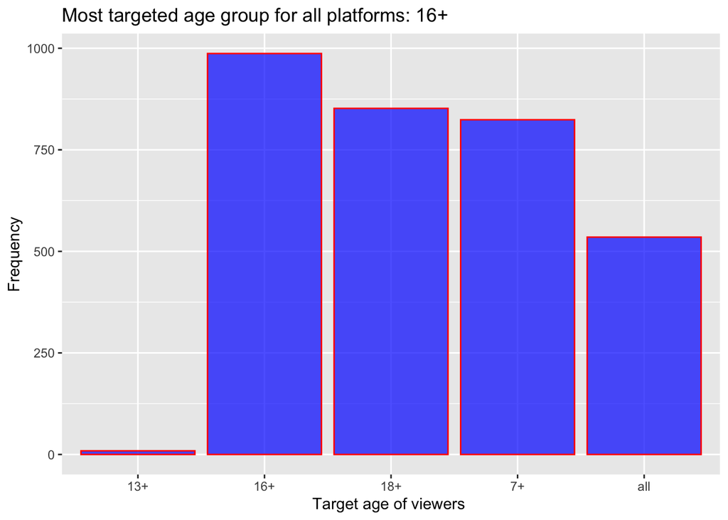

```r
print("Age:")
table(tvdata$Age)
prop.table(table(tvdata$Age))

ggplot(data = na.omit(tvdata), aes(Age)) +
  geom_bar(col="red",
                 fill="blue",
                 alpha = .7) + # opacity
  labs(title="Most targeted age group for all platforms: 16+ ") +
  labs(x="Target age of viewers ", y="Frequency")
```

```r
#I am taking this graph from above since it works for this question
```

people who are 16 and older are the most targeted age groups for the tv shows among the all steamming platfrom.

.Which year published the highest number of TV shows?

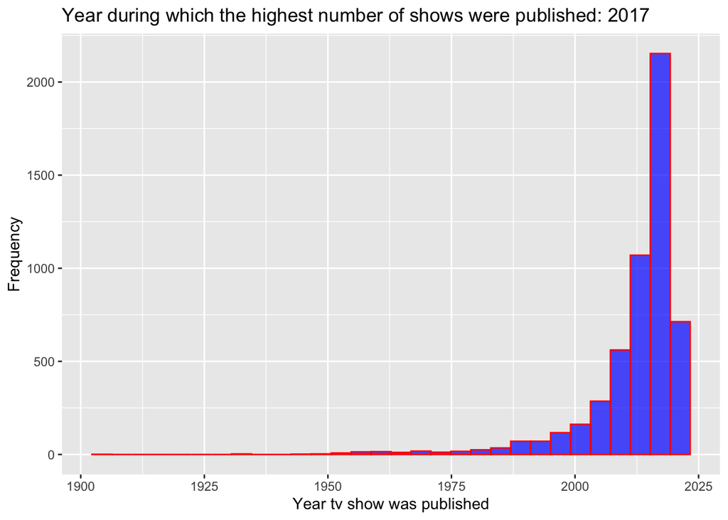

```r
print("Year:")
table(tvdata$Year)
library(ggplot2)
ggplot(data=tvdata, aes(Year)) +
  geom_histogram(bins = 30,
                 col="red",
           fill="blue",
           alpha = .7) + # opacity
  labs(title="Year during which the highest number of shows were published: 2017") +
  labs(x="Year tv show was published", y="Frequency")
```

```r
#I am replacing the prevous code with the graphs from above to keep the same formatting
```

Normality check of Variables

```r
netflixtv <- subset(tvdata, Netflix==1)
hulutv <- subset(tvdata, Hulu==1)
primetv <- subset(tvdata, Prime.Video==1)
disneytv <- subset(tvdata, Disney.==1)
```

#Smart Question:Which streaming platform has the highest average rating (according to Rotten Tomatoes and IMDb)?

On our dataset Netflix, Hulu, Prime tv, Disney+ are four streaming platforms. To find the highest average rating according to Rotten Tomatoes and IMDb among the four streaming platforms T-test is chosen for. A t-test is a type of inferential statistic used to compare the means of two groups. By conducting t-test, average rating value (mean value) of all streaming platforms has been found. Mean values from t-test are analyzed to find the highest average rating value.

```r
net_rating<-t.test(netflixtv$IMDb,netflixtv$Rotten.Tomatoes)
net_rating
hulu_rating<-t.test(hulutv$IMDb,hulutv$Rotten.Tomatoes)
hulu_rating
prime_rating<-t.test(primetv$IMDb,primetv$Rotten.Tomatoes)
prime_rating
disney_rating<-t.test(disneytv$IMDb,disneytv$Rotten.Tomatoes)
disney_rating
```

Prime Videos has the highest average IMDb rating which is 7.152538 among the all-streaming platforms. Netflix has the highest average Rotten Tomatoes rating which is 53.559107 among the all-streaming platforms. This is how the highest average rating is found.

#Normality check for IMDb and Rotten Tomatoes We have found the average value of IMDb and Rotten Tomatoes rating. Now, we want to check whether the samples of these two variables are normally distributed or not. If it is normally distributed the mean and median of the variable will be the same. #Normality check for the variables IMDb and Rotten Tomatoes for Netflix

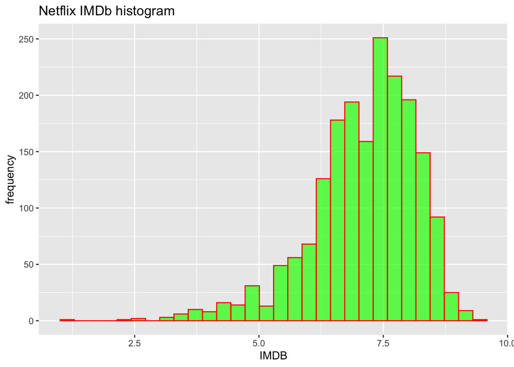

```r
shapiro.test(netflixtv$IMDb)
shapiro.test(netflixtv$Rotten.Tomatoes)

library(ggplot2)
ggplot(data=netflixtv,aes(x=IMDb,)) +
geom_histogram(col="red",
               fill="green",
               alpha = .7) +
labs(title="Netflix IMDb histogram") +
labs(x="IMDB", y="frequency")
```

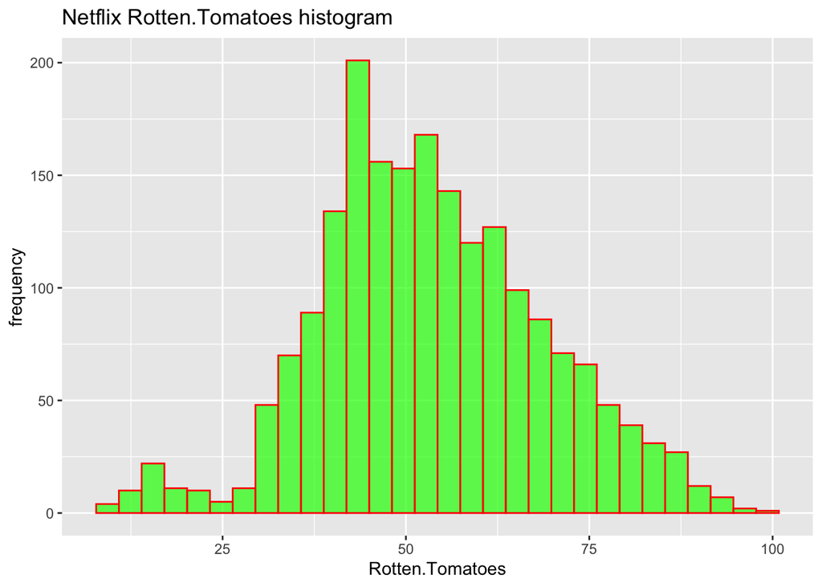

```r
ggplot(data=netflixtv,aes(x=Rotten.Tomatoes,)) +
geom_histogram(col="red",
               fill="green",
               alpha = .7) +
labs(title="Netflix Rotten.Tomatoes histogram") +
labs(x="Rotten.Tomatoes", y="frequency")
```

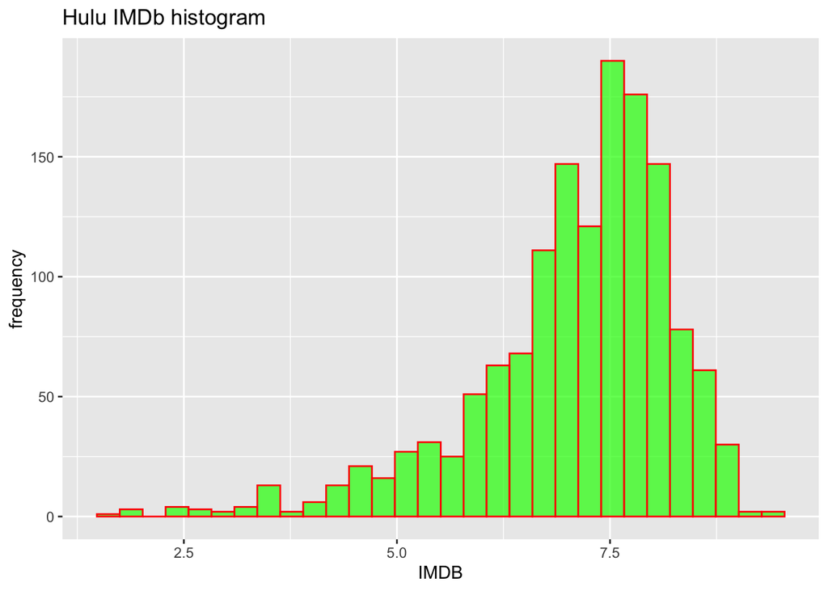

```r
shapiro.test(hulutv$IMDb)
shapiro.test(hulutv$Rotten.Tomatoes)

library(ggplot2)
ggplot(data=hulutv,aes(x=IMDb,)) +
geom_histogram(col="red",
               fill="green",
               alpha = .7) +
labs(title="Hulu IMDb histogram") +
labs(x="IMDB", y="frequency")
```

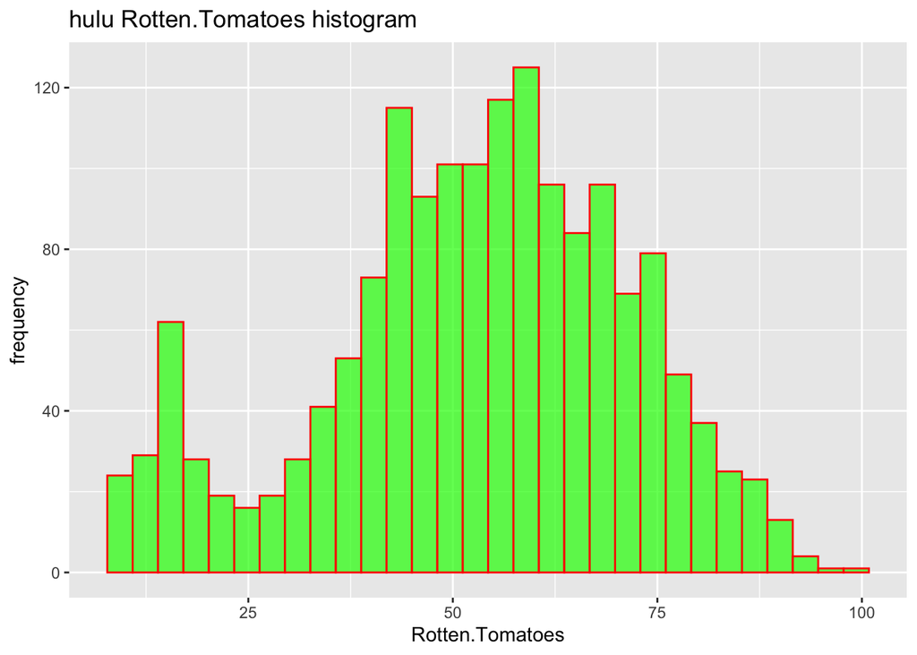

```r
ggplot(data=hulutv,aes(x=Rotten.Tomatoes,)) +
geom_histogram(col="red",
               fill="green",
               alpha = .7) +
labs(title="hulu Rotten.Tomatoes histogram") +
labs(x="Rotten.Tomatoes", y="frequency")
```

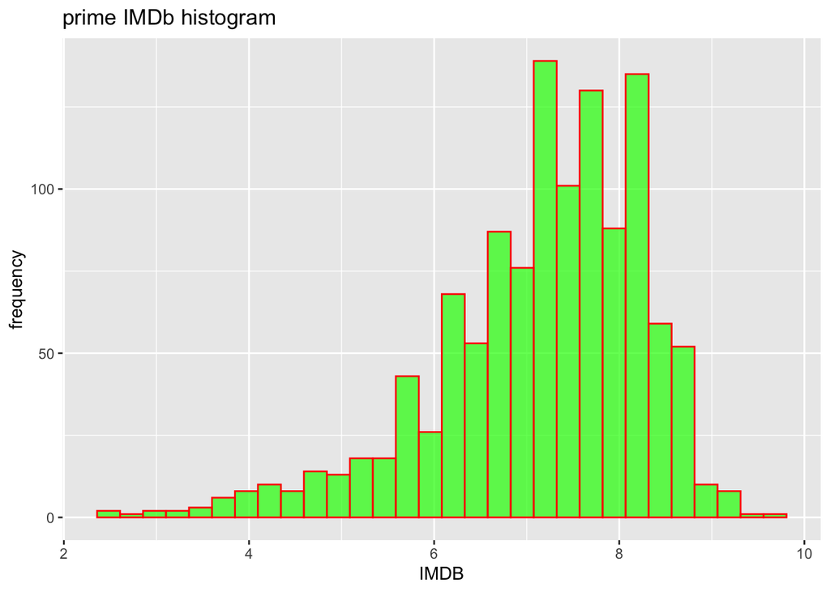

```r
shapiro.test(primetv$IMDb)
shapiro.test(primetv$Rotten.Tomatoes)
library(ggplot2)
ggplot(data=primetv,aes(x=IMDb,)) +
geom_histogram(col="red",
               fill="green",
               alpha = .7) +
labs(title="prime IMDb histogram") +
labs(x="IMDB", y="frequency")
```

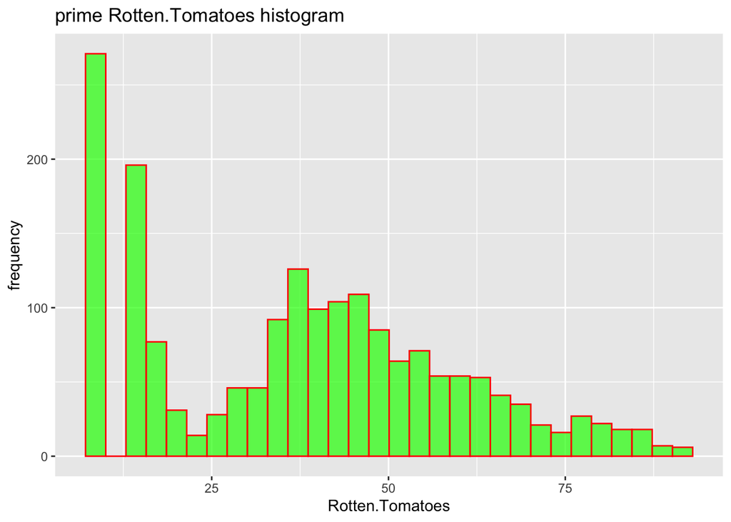

```r
ggplot(data=primetv,aes(x=Rotten.Tomatoes,)) +
geom_histogram(col="red",
               fill="green",
               alpha = .7) +
labs(title="prime Rotten.Tomatoes histogram") +
labs(x="Rotten.Tomatoes", y="frequency")
```

#Normality check for the variables IMDb and Rotten Tomatoes for Disney+

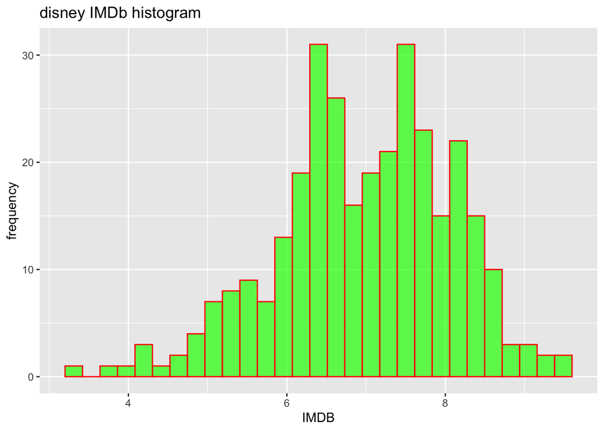

```r
shapiro.test(disneytv$IMDb)
shapiro.test(disneytv$Rotten.Tomatoes)
library(ggplot2)
ggplot(data=disneytv,aes(x=IMDb,)) +
geom_histogram(col="red",
               fill="green",
               alpha = .7) +
labs(title="disney IMDb histogram") +
labs(x="IMDB", y="frequency")
```

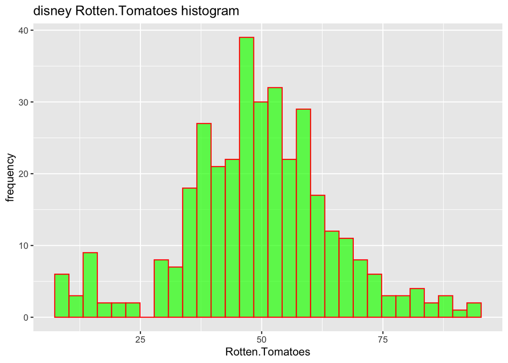

```r
ggplot(data=disneytv,aes(x=Rotten.Tomatoes,)) +
geom_histogram(col="red",
               fill="green",
               alpha = .7) +
labs(title="disney Rotten.Tomatoes histogram") +
labs(x="Rotten.Tomatoes", y="frequency")
```

#SMART Question: Do the rating IMDb and Rotten Tomatoes depend on age variable?

We want to check the rating of streaming platforms on IMDb and Rotten Tomatoes are somehow related to the age of the audience. We conduct a chi-square test to check whether IMDb and Rotten Tomatoes are independent. H0: Age and rating are independent from each other. H1: Age and rating are not independent from each other.

#Independence check for Netflix platform

```r
contable1= table(netflixtv$Age, netflixtv$IMDb)
contable1
chitest1 = chisq.test(contable1)
chitest1

contable2 = table(netflixtv$Age, netflixtv$Rotten.Tomatoes)
contable2
chitest2 = chisq.test(contable2)
chitest2
```

Since the p-value is 0, which is lower than 0.05, we need to reject the null hypothesis. Thus, IMDb and Rotten Tomatoes ratings for Netflix are not independent. Age and rating are correlated for Netflix platform.

#Independence check for Hulu platform

```r
contable3= table(hulutv$Age, hulutv$IMDb)
contable3
chitest3 = chisq.test(contable3)
chitest3

contable4 = table(hulutv$Age, hulutv$Rotten.Tomatoes)
contable4
chitest4 = chisq.test(contable4)
chitest4
```

```r
contable5= table(primetv$Age, primetv$IMDb)
contable5
chitest5 = chisq.test(contable5)
chitest5

contable6 = table(primetv$Age, primetv$Rotten.Tomatoes)
contable6
chitest6 = chisq.test(contable6)
chitest6
```

Since the p-value for IMDb is 0.002 the p-value for Rotten Tomatoes is 2e-16, which are less than 0.05. we need to reject the null hypothesis. Thus, IMDb and Rotten Tomatoes rating for Prime tv are not independent. Age and rating are correlated for Prime tv platform. #Independence check for Disney+ platform

```r
contable7= table(disneytv$Age, disneytv$IMDb)
contable7
chitest7 = chisq.test(contable7)
chitest7

contable8 = table(disneytv$Age, disneytv$Rotten.Tomatoes)
contable8
chitest8= chisq.test(contable8)
chitest8
```

Since the p-value is 0, which is lower than 0.05, we need to reject the null hypothesis. Thus, IMDb and Rotten Tomatoes ratings for Disney+ are not independent. Age and rating are correlated for Disney+ platform.